# Supplementary Stress Evaluation — L1 vs S1 near capacity

**This notebook is supplementary to, and does not replace or reinterpret, the primary 18-run formal experiment analyzed in `formal_results_analysis.ipynb`.** That experiment found that at a fixed 50 QPS neither architecture shows meaningful p95 degradation under concurrent indexing (`D_p95` mostly 0.7-1.0) — plausibly because 50 QPS never puts either system under real load pressure (p95 latencies were only ~5-8ms, CPU stayed low in both architectures).

This experiment instead pushes each architecture toward its own approximate capacity ceiling before comparing query-only vs. query+write behavior, to test whether the same "no measurable degradation" finding still holds under load pressure, or whether it was an artifact of running far below capacity.

## Method

No artificial workload-distorting tricks (forced merges, `refresh=true`, tiny heaps, slow disks, RAM starvation) were used — same corpus, same query set, same Docker resource limits as the primary experiment (`experiment-config.json`, untouched).

**Deferred**: an "L1-R" replica-only-routing control was considered and explicitly deferred (not implemented) — OpenSearch has no supported `preference=_replica` mechanism and L1 has no allocation-awareness config to safely pin shard placement.

All 12 stress runs are valid (see `results/stress/<system>/<workload>/r<n>/validity.json`).

```python
import json
from pathlib import Path

import matplotlib.pyplot as plt
import numpy as np
import pandas as pd

PROJECT_ROOT = Path.cwd().parent if Path.cwd().name == "notebooks" else Path.cwd()
RESULTS_ROOT = PROJECT_ROOT / "results" / "stress"

with open(PROJECT_ROOT / "stress-experiment-config.json") as f:
    STRESS_CONFIG = json.load(f)

SYSTEMS = ["local_index", "shared_index"]
SYSTEM_LABEL = {"local_index": "L1", "shared_index": "S1"}
WORKLOADS = ["stress_w0", "stress_w2"]
WORKLOADS_UPPER = ["Stress-W0", "Stress-W2"]
WORKLOAD_DIR_TO_LABEL = {"stress_w0": "Stress-W0", "stress_w2": "Stress-W2"}
REPS = [1, 2, 3]

QPS_STRESS = STRESS_CONFIG["qps_stress"]
MAX_SUSTAINABLE_QPS = STRESS_CONFIG["max_sustainable_qps"]

# Matches run_stress.py's WARMUP_S/LEAD_IN_S/MEASUREMENT_S (180s / 30s / 480s):
# Stress-W0 has no lead-in (pure 480s measurement); Stress-W2 discards a 30s
# lead-in from a 510s combined query+write stream so the write pipeline isn't
# cold at t=0 -- same convention as the primary experiment's W1/W2.
LEAD_IN_S = {"stress_w0": 0.0, "stress_w2": 30.0}
MEASUREMENT_S = 480.0

SYSTEM_COLOR = {"L1": "#4C72B0", "S1": "#DD8452"}
RNG = np.random.default_rng(0)

print(f"QPS_stress = {QPS_STRESS} (max_sustainable_qps: L1={MAX_SUSTAINABLE_QPS['local_index']}, S1={MAX_SUSTAINABLE_QPS['shared_index']})")
```

```
QPS_stress = 1120 (max_sustainable_qps: L1=1500, S1=1600)
```

## Capacity-staircase probe results

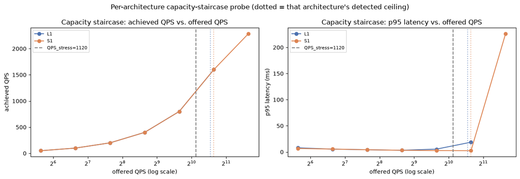

```
L1: detected_knee_qps=1600.0, max_sustainable_qps=1500.0
S1: detected_knee_qps=3200.0, max_sustainable_qps=1600.0
```

```python
def _load_capacity_report(system: str) -> dict:
    with open(RESULTS_ROOT / "capacity" / f"{system}_capacity_report.json") as f:
        return json.load(f)


capacity_reports = {system: _load_capacity_report(system) for system in SYSTEMS}

fig, axes = plt.subplots(1, 2, figsize=(13, 4.5))
for ax, metric, ylabel in zip(axes, ["achieved_qps", "latency_ms_p95_overall"], ["achieved QPS", "p95 latency (ms)"]):
    for system in SYSTEMS:
        label = SYSTEM_LABEL[system]
        rungs = [r for r in capacity_reports[system]["rungs"] if not r.get("is_refinement")]
        rungs.sort(key=lambda r: r["offered_qps"])
        xs = [r["offered_qps"] for r in rungs]
        ys = [r[metric] for r in rungs]
        ax.plot(xs, ys, marker="o", color=SYSTEM_COLOR[label], label=label)
        ax.axvline(MAX_SUSTAINABLE_QPS[system], color=SYSTEM_COLOR[label], linestyle=":", alpha=0.6)
    ax.axvline(QPS_STRESS, color="gray", linestyle="--", linewidth=1.5, label=f"QPS_stress={QPS_STRESS}")
    ax.set_xscale("log", base=2)
    ax.set_xlabel("offered QPS (log scale)")
    ax.set_ylabel(ylabel)
    ax.legend(fontsize=8)
axes[0].set_title("Capacity staircase: achieved QPS vs. offered QPS")
axes[1].set_title("Capacity staircase: p95 latency vs. offered QPS")
fig.suptitle("Per-architecture capacity-staircase probe (dotted = that architecture's detected ceiling)")
fig.tight_layout()
plt.show()

for system in SYSTEMS:
    r = capacity_reports[system]
    print(f"{SYSTEM_LABEL[system]}: detected_knee_qps={r['detected_knee_qps']}, max_sustainable_qps={r['max_sustainable_qps']}")
```

## Load all 12 stress-run bundles into one tidy DataFrame

```python
def _load_json(path: Path) -> dict | None:
    if not path.exists():
        return None
    with open(path) as f:
        return json.load(f)


def _container_totals(container_summary: dict | None) -> dict:
    if not container_summary:
        return {"cpu_pct_avg_total": np.nan, "cpu_pct_max_total": np.nan, "mem_mb_avg_total": np.nan, "mem_mb_max_total": np.nan}
    return {
        "cpu_pct_avg_total": sum(c["cpu_pct_avg"] for c in container_summary.values()),
        "cpu_pct_max_total": max(c["cpu_pct_max"] for c in container_summary.values()),
        "mem_mb_avg_total": sum(c["mem_mb_avg"] for c in container_summary.values()),
        "mem_mb_max_total": max(c["mem_mb_max"] for c in container_summary.values()),
    }


rows = []
for system in SYSTEMS:
    for workload in WORKLOADS:
        for rep in REPS:
            run_dir = RESULTS_ROOT / system / workload / f"r{rep}"
            metadata = _load_json(run_dir / "metadata.json")
            validity = _load_json(run_dir / "validity.json")
            query_summary = _load_json(run_dir / "query_summary.json")
            indexing_summary = _load_json(run_dir / "indexing_summary.json")
            container_summary = _load_json(run_dir / "container_stats_summary.json")

            if metadata is None or query_summary is None:
                print(f"MISSING: {run_dir}")
                continue

            row = {
                "system": SYSTEM_LABEL[system],
                "workload": WORKLOAD_DIR_TO_LABEL[workload],
                "repetition": rep,
                "position": metadata["position"],
                "valid": validity["valid"] if validity else metadata["valid"],
                "achieved_qps": query_summary["achieved_qps"],
                "target_qps": query_summary["target_qps"],
                "query_error_rate_pct": query_summary["error_rate_pct"],
                "query_p50_ms": query_summary["latency_ms_p50_overall"],
                "query_p95_ms": query_summary["latency_ms_p95_overall"],
                "query_p95_ms_first_half": query_summary["latency_ms_p95_first_half"],
                "query_p95_ms_second_half": query_summary["latency_ms_p95_second_half"],
                "achieved_docs_per_s": indexing_summary["achieved_docs_per_s"] if indexing_summary else np.nan,
                "target_docs_per_s": indexing_summary["target_docs_per_s"] if indexing_summary else 0,
                "item_errors_count": indexing_summary["item_errors_count"] if indexing_summary else 0,
                **_container_totals(container_summary),
            }
            rows.append(row)

runs = pd.DataFrame(rows)
runs["workload"] = pd.Categorical(runs["workload"], categories=WORKLOADS_UPPER, ordered=True)
print(f"Loaded {len(runs)} runs (expected 12); all valid: {runs['valid'].all()}")
runs.sort_values("position").reset_index(drop=True)
```

```
Loaded 12 runs (expected 12); all valid: True
```

|  | system | workload | repetition | position | valid | achieved_qps | target_qps | query_error_rate_pct | query_p50_ms | query_p95_ms | query_p95_ms_first_half | query_p95_ms_second_half | achieved_docs_per_s | target_docs_per_s | item_errors_count | cpu_pct_avg_total | cpu_pct_max_total | mem_mb_avg_total | mem_mb_max_total |
| --- | --- | --- | --- | --- | --- | --- | --- | --- | --- | --- | --- | --- | --- | --- | --- | --- | --- | --- | --- |
| 0 | L1 | Stress-W0 | 1 | 1 | True | 1119.61 | 1120 | 0.0 | 1.835833 | 3.136708 | 3.118541 | 3.154594 | NaN | 0 | 0 | 142.11 | 205.92 | 3134.2 | 1725.4 |
| 1 | L1 | Stress-W2 | 1 | 2 | True | 1119.53 | 1120 | 0.0 | 1.814833 | 3.338125 | 3.368750 | 3.309046 | 500.07 | 500 | 0 | 152.82 | 215.29 | 3054.6 | 1550.3 |
| 2 | S1 | Stress-W0 | 1 | 3 | True | 1119.60 | 1120 | 0.0 | 1.771458 | 3.914917 | 3.885083 | 3.944338 | NaN | 0 | 0 | 138.67 | 208.20 | 3187.0 | 1744.9 |
| 3 | S1 | Stress-W2 | 1 | 4 | True | 1119.56 | 1120 | 0.0 | 1.603041 | 3.658375 | 3.251333 | 4.152300 | 499.59 | 500 | 0 | 131.34 | 207.93 | 3138.8 | 1635.3 |
| 4 | S1 | Stress-W2 | 2 | 5 | True | 1113.07 | 1120 | 0.0 | 3.987042 | 56.709500 | 9.402141 | 62.284881 | 499.77 | 500 | 0 | 170.50 | 213.74 | 3139.5 | 1672.2 |
| 5 | S1 | Stress-W0 | 2 | 6 | True | 1119.58 | 1120 | 0.0 | 1.722833 | 7.818625 | 7.432599 | 8.178000 | NaN | 0 | 0 | 139.07 | 210.77 | 3144.9 | 1711.1 |
| 6 | L1 | Stress-W2 | 2 | 7 | True | 1119.34 | 1120 | 0.0 | 2.633709 | 9.690125 | 8.706721 | 10.593792 | 500.06 | 500 | 0 | 213.89 | 210.56 | 3054.9 | 1548.3 |
| 7 | L1 | Stress-W0 | 2 | 8 | True | 1119.60 | 1120 | 0.0 | 1.902459 | 4.230542 | 5.085760 | 3.150692 | NaN | 0 | 0 | 167.71 | 210.65 | 3078.7 | 1703.9 |
| 8 | L1 | Stress-W0 | 3 | 9 | True | 1119.57 | 1120 | 0.0 | 1.838708 | 3.263375 | 3.339834 | 3.195383 | NaN | 0 | 0 | 140.61 | 207.88 | 3173.5 | 1718.3 |
| 9 | L1 | Stress-W2 | 3 | 10 | True | 1119.49 | 1120 | 0.0 | 1.898041 | 3.747959 | 3.944162 | 3.560173 | 500.06 | 500 | 0 | 161.11 | 205.20 | 3053.4 | 1549.3 |
| 10 | S1 | Stress-W0 | 3 | 11 | True | 1119.57 | 1120 | 0.0 | 1.606292 | 3.538125 | 3.479421 | 3.606316 | NaN | 0 | 0 | 133.88 | 215.46 | 3192.5 | 1751.0 |
| 11 | S1 | Stress-W2 | 3 | 12 | True | 1119.48 | 1120 | 0.0 | 1.711750 | 4.823250 | 4.508646 | 5.121175 | 500.00 | 500 | 0 | 150.01 | 207.33 | 3139.5 | 1647.6 |

## Reusable dot + median + min-max plot helper

Same presentation convention as the primary notebook: every one of the 3 repetitions is plotted as its own point, with a median marker and a min-max range bar, rather than collapsing to mean +/- std (n=3 is too small for std to be a stable/trustworthy summary).

```python
def plot_dot_median(ax, df, metric, title=None, ylabel=None, ref_line=None,
                    systems=("L1", "S1"), workloads=WORKLOADS_UPPER, jitter=0.04):
    x = np.arange(len(workloads))
    n = len(systems)
    span = 0.3
    offsets = {s: (i - (n - 1) / 2) * (span / max(n - 1, 1)) for i, s in enumerate(systems)}

    for system in systems:
        for i, wl in enumerate(workloads):
            vals = df[(df["system"] == system) & (df["workload"] == wl)][metric].dropna().to_numpy()
            if len(vals) == 0:
                continue
            xs = x[i] + offsets[system] + RNG.uniform(-jitter, jitter, size=len(vals))
            ax.scatter(xs, vals, color=SYSTEM_COLOR[system], alpha=0.85, zorder=3, s=45,
                       label=system if i == 0 else None)
            med = np.median(vals)
            ax.plot([x[i] + offsets[system] - 0.09, x[i] + offsets[system] + 0.09], [med, med],
                    color=SYSTEM_COLOR[system], linewidth=2.8, zorder=4)
            if len(vals) > 1:
                ax.vlines(x[i] + offsets[system], vals.min(), vals.max(),
                          color=SYSTEM_COLOR[system], alpha=0.35, linewidth=1.5, zorder=2)

    if ref_line is not None:
        ax.axhline(ref_line, color="gray", linestyle="--", linewidth=1, zorder=1)
    ax.set_xticks(x)
    ax.set_xticklabels(workloads)
    if title:
        ax.set_title(title)
    if ylabel:
        ax.set_ylabel(ylabel)
    ax.legend()
```

## Primary result 1: individual-run query latency at QPS_stress

Dots = each of the 3 repetitions; thick tick = median; thin vertical bar = observed min-max range.

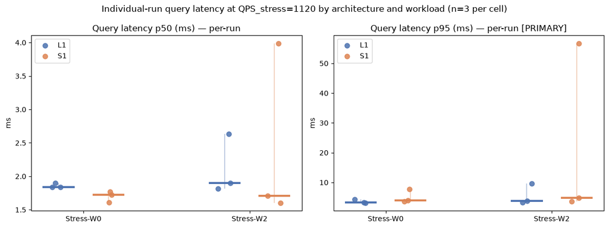

```python
fig, axes = plt.subplots(1, 2, figsize=(12, 4.5))
plot_dot_median(axes[0], runs, "query_p50_ms", "Query latency p50 (ms) — per-run", "ms")
plot_dot_median(axes[1], runs, "query_p95_ms", "Query latency p95 (ms) — per-run [PRIMARY]", "ms")
fig.suptitle(f"Individual-run query latency at QPS_stress={QPS_STRESS} by architecture and workload (n=3 per cell)")
fig.tight_layout()
plt.show()
```

## Primary result 2: p95 degradation ratio under stress — THE key figure

`D_p95_stress = p95(Stress-W2) / p95(Stress-W0)`, computed **per repetition, per architecture** — same convention as the primary experiment's `D_p95`, just at `QPS_stress` instead of 50 QPS. This is the figure to compare directly against the primary notebook's "Primary result 2":

- `D > 1`: concurrent indexing degraded query latency relative to that architecture's own query-only baseline, *even under near-capacity load*.
- `D <= 1`: no measurable degradation was observed even when the system is pushed much closer to its ceiling — reinforcing (rather than merely failing to contradict) the primary experiment's finding.

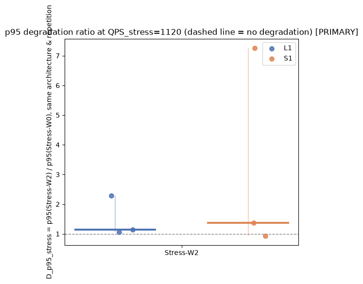

```
Per-repetition p95 degradation ratios under stress (primary):
```

|  | system | repetition | p95_w0 | p95_load | p95_ratio | p50_ratio |
| --- | --- | --- | --- | --- | --- | --- |
| 0 | L1 | 1 | 3.136708 | 3.338125 | 1.064213 | 0.988561 |
| 1 | L1 | 2 | 4.230542 | 9.690125 | 2.290516 | 1.384371 |
| 2 | L1 | 3 | 3.263375 | 3.747959 | 1.148492 | 1.032269 |
| 3 | S1 | 1 | 3.914917 | 3.658375 | 0.934471 | 0.904927 |
| 4 | S1 | 2 | 7.818625 | 56.709500 | 7.253130 | 2.314236 |
| 5 | S1 | 3 | 3.538125 | 4.823250 | 1.363222 | 1.065653 |

```python
ratio_rows = []
for system in ["L1", "S1"]:
    base = runs[(runs["system"] == system) & (runs["workload"] == "Stress-W0")].set_index("repetition")
    cur = runs[(runs["system"] == system) & (runs["workload"] == "Stress-W2")].set_index("repetition")
    for rep in REPS:
        if rep in base.index and rep in cur.index:
            ratio_rows.append({
                "system": system, "workload": "Stress-W2", "repetition": rep,
                "p95_ratio": cur.loc[rep, "query_p95_ms"] / base.loc[rep, "query_p95_ms"],
                "p50_ratio": cur.loc[rep, "query_p50_ms"] / base.loc[rep, "query_p50_ms"],
                "p95_w0": base.loc[rep, "query_p95_ms"], "p95_load": cur.loc[rep, "query_p95_ms"],
            })
ratio_df = pd.DataFrame(ratio_rows)

fig, ax = plt.subplots(figsize=(5.5, 5))
plot_dot_median(ax, ratio_df, "p95_ratio", ref_line=1.0, workloads=["Stress-W2"])
ax.set_ylabel("D_p95_stress = p95(Stress-W2) / p95(Stress-W0), same architecture & repetition")
ax.set_title(f"p95 degradation ratio at QPS_stress={QPS_STRESS} (dashed line = no degradation) [PRIMARY]")
fig.tight_layout()
plt.show()

print("Per-repetition p95 degradation ratios under stress (primary):")
ratio_df.sort_values(["system", "repetition"])[["system", "repetition", "p95_w0", "p95_load", "p95_ratio", "p50_ratio"]]
```

## Side-by-side comparison with the primary (50 QPS) experiment

Loads the primary experiment's `D_p95` (W1/W2 vs. W0) alongside this experiment's `D_p95_stress` (Stress-W2 vs. Stress-W0) to see whether the "no measurable degradation" finding holds, weakens, or reverses as load increases from 50 QPS to `QPS_stress`.

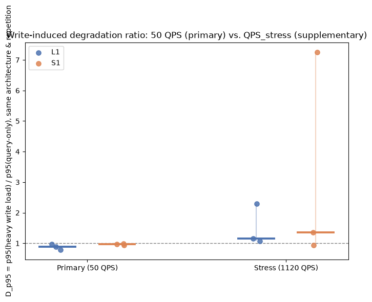

|  | system | regime | workload | repetition | p95_ratio |
| --- | --- | --- | --- | --- | --- |
| 0 | L1 | Primary (50 QPS) | W2-equivalent | 1 | 0.787141 |
| 1 | L1 | Primary (50 QPS) | W2-equivalent | 2 | 0.891861 |
| 2 | L1 | Primary (50 QPS) | W2-equivalent | 3 | 0.971610 |
| 3 | L1 | Stress (1120 QPS) | W2-equivalent | 1 | 1.064213 |
| 4 | L1 | Stress (1120 QPS) | W2-equivalent | 2 | 2.290516 |
| 5 | L1 | Stress (1120 QPS) | W2-equivalent | 3 | 1.148492 |
| 6 | S1 | Primary (50 QPS) | W2-equivalent | 1 | 0.968857 |
| 7 | S1 | Primary (50 QPS) | W2-equivalent | 2 | 0.993950 |
| 8 | S1 | Primary (50 QPS) | W2-equivalent | 3 | 0.937794 |
| 9 | S1 | Stress (1120 QPS) | W2-equivalent | 1 | 0.934471 |
| 10 | S1 | Stress (1120 QPS) | W2-equivalent | 2 | 7.253130 |
| 11 | S1 | Stress (1120 QPS) | W2-equivalent | 3 | 1.363222 |

```python
FORMAL_RESULTS_ROOT = PROJECT_ROOT / "results" / "formal"

formal_ratio_rows = []
for system_dir, system in [("local_index", "L1"), ("shared_index", "S1")]:
    base = {}
    for rep in REPS:
        qs = _load_json(FORMAL_RESULTS_ROOT / system_dir / "w0" / f"r{rep}" / "query_summary.json")
        if qs is not None:
            base[rep] = qs["latency_ms_p95_overall"]
    for workload in ["w1", "w2"]:
        for rep in REPS:
            qs = _load_json(FORMAL_RESULTS_ROOT / system_dir / workload / f"r{rep}" / "query_summary.json")
            if qs is not None and rep in base:
                formal_ratio_rows.append({
                    "system": system, "regime": "Primary (50 QPS)", "workload": workload.upper(),
                    "repetition": rep, "p95_ratio": qs["latency_ms_p95_overall"] / base[rep],
                })
formal_ratio_df = pd.DataFrame(formal_ratio_rows)

stress_only_w2 = ratio_df.copy()
stress_only_w2["regime"] = f"Stress ({QPS_STRESS} QPS)"
stress_only_w2["workload"] = "W2-equivalent"

combined = pd.concat([
    formal_ratio_df[formal_ratio_df["workload"] == "W2"].assign(workload="W2-equivalent"),
    stress_only_w2[["system", "regime", "workload", "repetition", "p95_ratio"]],
], ignore_index=True)

fig, ax = plt.subplots(figsize=(7, 5))
regimes = ["Primary (50 QPS)", f"Stress ({QPS_STRESS} QPS)"]
x = np.arange(len(regimes))
span = 0.3
offsets = {s: (i - 0.5) * (span / 1) for i, s in enumerate(["L1", "S1"])}
for system in ["L1", "S1"]:
    for i, regime in enumerate(regimes):
        vals = combined[(combined["system"] == system) & (combined["regime"] == regime)]["p95_ratio"].to_numpy()
        if len(vals) == 0:
            continue
        xs = x[i] + offsets[system] + RNG.uniform(-0.04, 0.04, size=len(vals))
        ax.scatter(xs, vals, color=SYSTEM_COLOR[system], alpha=0.85, zorder=3, s=45, label=system if i == 0 else None)
        med = np.median(vals)
        ax.plot([x[i] + offsets[system] - 0.09, x[i] + offsets[system] + 0.09], [med, med],
                color=SYSTEM_COLOR[system], linewidth=2.8, zorder=4)
        if len(vals) > 1:
            ax.vlines(x[i] + offsets[system], vals.min(), vals.max(), color=SYSTEM_COLOR[system], alpha=0.35, linewidth=1.5, zorder=2)
ax.axhline(1.0, color="gray", linestyle="--", linewidth=1)
ax.set_xticks(x)
ax.set_xticklabels(regimes)
ax.set_ylabel("D_p95 = p95(heavy write load) / p95(query-only), same architecture & repetition")
ax.set_title("Write-induced degradation ratio: 50 QPS (primary) vs. QPS_stress (supplementary)")
ax.legend()
fig.tight_layout()
plt.show()

combined.sort_values(["system", "regime", "repetition"]).reset_index(drop=True)
```

## Diagnostic 1: achieved QPS sanity check across all 12 runs

Confirms the validity gate held: every run should sit essentially at the `QPS_stress` target regardless of concurrent indexing load.

```python
print(f"achieved_qps range across all 12 runs: [{runs['achieved_qps'].min():.3f}, {runs['achieved_qps'].max():.3f}] (target {QPS_STRESS})")
runs.pivot_table(index=["system", "workload"], columns="repetition", values="achieved_qps", observed=True)
```

```
achieved_qps range across all 12 runs: [1113.070, 1119.610] (target 1120)
```

| system | repetition workload | 1 | 2 | 3 |
| --- | --- | --- | --- | --- |
| L1 | Stress-W0 | 1119.61 | 1119.60 | 1119.57 |
|  | Stress-W2 | 1119.53 | 1119.34 | 1119.49 |
| S1 | Stress-W0 | 1119.60 | 1119.58 | 1119.57 |
|  | Stress-W2 | 1119.56 | 1113.07 | 1119.48 |

## Diagnostic 2: run-order effect

Runs were executed in a fixed, balanced order (not grouped by condition), same as the primary experiment, to guard against order/time confounds.

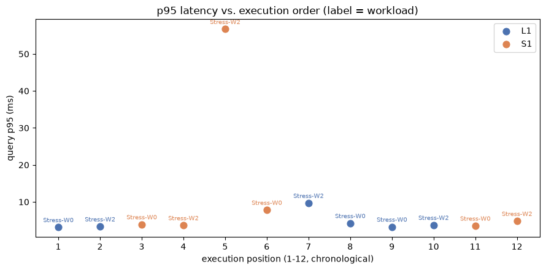

```python
fig, ax = plt.subplots(figsize=(9, 4.5))
for system in ["L1", "S1"]:
    sub = runs[runs["system"] == system].sort_values("position")
    ax.scatter(sub["position"], sub["query_p95_ms"], color=SYSTEM_COLOR[system], label=system, s=60, zorder=3)
    for _, r in sub.iterrows():
        ax.annotate(r["workload"], (r["position"], r["query_p95_ms"]), fontsize=7,
                    xytext=(0, 6), textcoords="offset points", ha="center", color=SYSTEM_COLOR[system])
ax.set_xlabel("execution position (1-12, chronological)")
ax.set_ylabel("query p95 (ms)")
ax.set_title("p95 latency vs. execution order (label = workload)")
ax.set_xticks(range(1, 13))
ax.legend()
fig.tight_layout()
plt.show()
```

## Diagnostic 3: resource usage (CPU / memory) per run

Under QPS_stress, both architectures should show materially higher CPU utilization than the primary experiment's 50 QPS runs (~28-35% avg there) if the stress condition is actually exercising more capacity.

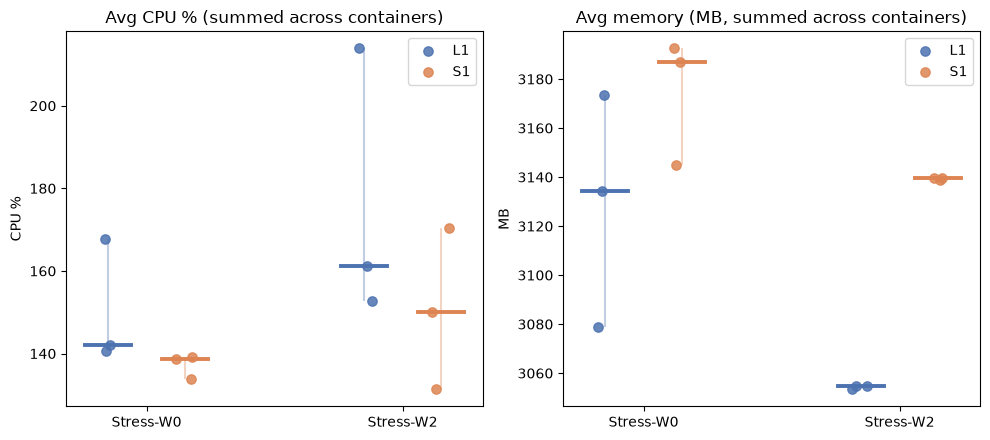

```python
fig, axes = plt.subplots(1, 2, figsize=(10, 4.5))
plot_dot_median(axes[0], runs, "cpu_pct_avg_total", "Avg CPU % (summed across containers)", "CPU %")
plot_dot_median(axes[1], runs, "mem_mb_avg_total", "Avg memory (MB, summed across containers)", "MB")
fig.tight_layout()
plt.show()
```

## Diagnostic 4: within-run latency drift over the 480s measurement window

Buckets each run's queries into 10s windows and plots bucket-p95 over time — reveals whether an aggregate p95 is hiding a warm-up tail, a spike, or slow drift within the longer 480s window used here (vs. 300s in the primary experiment).

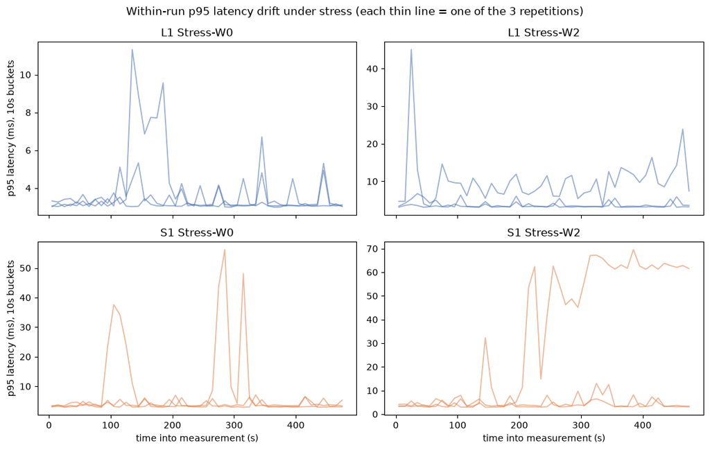

```python
BUCKET_S = 10


def load_measurement_queries(system_dir: str, workload_dir: str, rep: int) -> pd.DataFrame:
    path = RESULTS_ROOT / system_dir / workload_dir / f"r{rep}" / "queries.csv"
    df = pd.read_csv(path)
    lead_in = LEAD_IN_S[workload_dir]
    df = df[df["tick_offset_s"] >= lead_in].copy()
    df["time_s"] = df["tick_offset_s"] - lead_in
    return df


def bucket_p95(df: pd.DataFrame, bucket_s: float = BUCKET_S, measurement_s: float = MEASUREMENT_S) -> pd.Series:
    bins = np.arange(0, measurement_s + bucket_s, bucket_s)
    labels = bins[:-1] + bucket_s / 2
    df = df.copy()
    df["bucket_mid"] = pd.cut(df["time_s"], bins=bins, right=False, labels=labels)
    return df.groupby("bucket_mid", observed=True)["latency_ms"].quantile(0.95)


SYSTEM_DIRS = {"L1": "local_index", "S1": "shared_index"}

fig, axes = plt.subplots(2, 2, figsize=(11, 7), sharex=True)
for row, system in enumerate(["L1", "S1"]):
    for col, workload_dir in enumerate(["stress_w0", "stress_w2"]):
        ax = axes[row, col]
        for rep in REPS:
            q = load_measurement_queries(SYSTEM_DIRS[system], workload_dir, rep)
            series = bucket_p95(q)
            ax.plot(series.index.astype(float), series.values, color=SYSTEM_COLOR[system], alpha=0.55, linewidth=1.3)
        ax.set_title(f"{system} {WORKLOAD_DIR_TO_LABEL[workload_dir]}")
        if row == 1:
            ax.set_xlabel("time into measurement (s)")
        if col == 0:
            ax.set_ylabel("p95 latency (ms), 10s buckets")

fig.suptitle("Within-run p95 latency drift under stress (each thin line = one of the 3 repetitions)")
fig.tight_layout()
plt.show()
```

## Diagnostic 5: indexing throughput fidelity under Stress-W2

Confirms the 500 docs/s write target was actually achieved at QPS_stress concurrently, not silently throttled by query-load contention.

```python
w2_runs = runs[runs["workload"] == "Stress-W2"]
print(f"achieved_docs_per_s range across Stress-W2 runs: [{w2_runs['achieved_docs_per_s'].min():.2f}, {w2_runs['achieved_docs_per_s'].max():.2f}] (target 500)")
w2_runs[["system", "repetition", "achieved_docs_per_s", "item_errors_count"]].sort_values(["system", "repetition"]).reset_index(drop=True)
```

```
achieved_docs_per_s range across Stress-W2 runs: [499.59, 500.07] (target 500)
```

|  | system | repetition | achieved_docs_per_s | item_errors_count |
| --- | --- | --- | --- | --- |
| 0 | L1 | 1 | 500.07 | 0 |
| 1 | L1 | 2 | 500.06 | 0 |
| 2 | L1 | 3 | 500.06 | 0 |
| 3 | S1 | 1 | 499.59 | 0 |
| 4 | S1 | 2 | 499.77 | 0 |
| 5 | S1 | 3 | 500.00 | 0 |

## Exploratory reference: mean +/- std summary table

Kept for completeness, but **not** the primary presentation given n=3 — see the dot/median figures above instead.

```python
metrics = [
    "achieved_qps", "query_error_rate_pct", "query_p50_ms", "query_p95_ms",
    "achieved_docs_per_s", "item_errors_count",
    "cpu_pct_avg_total", "mem_mb_avg_total",
]


def fmt_mean_std(s: pd.Series) -> str:
    if s.isna().all():
        return "-"
    return f"{s.mean():.2f} +/- {s.std():.2f}"


summary = (
    runs.groupby(["system", "workload"], observed=True)[metrics]
    .agg(fmt_mean_std)
    .unstack("system")
    .swaplevel(axis=1)
    .sort_index(axis=1, level=0)
)
summary
```

| system workload | L1 achieved_docs_per_s | L1 achieved_qps | L1 cpu_pct_avg_total | L1 item_errors_count | L1 mem_mb_avg_total | L1 query_error_rate_pct | L1 query_p50_ms | L1 query_p95_ms | S1 achieved_docs_per_s | S1 achieved_qps | S1 cpu_pct_avg_total | S1 item_errors_count | S1 mem_mb_avg_total | S1 query_error_rate_pct | S1 query_p50_ms | S1 query_p95_ms |
| --- | --- | --- | --- | --- | --- | --- | --- | --- | --- | --- | --- | --- | --- | --- | --- | --- |
| Stress-W0 | - | 1119.59 +/- 0.02 | 150.14 +/- 15.23 | 0.00 +/- 0.00 | 3128.80 +/- 47.63 | 0.00 +/- 0.00 | 1.86 +/- 0.04 | 3.54 +/- 0.60 | - | 1119.58 +/- 0.02 | 137.21 +/- 2.89 | 0.00 +/- 0.00 | 3174.80 +/- 26.04 | 0.00 +/- 0.00 | 1.70 +/- 0.08 | 5.09 +/- 2.37 |
| Stress-W2 | 500.06 +/- 0.01 | 1119.45 +/- 0.10 | 175.94 +/- 33.13 | 0.00 +/- 0.00 | 3054.30 +/- 0.79 | 0.00 +/- 0.00 | 2.12 +/- 0.45 | 5.59 +/- 3.55 | 499.79 +/- 0.21 | 1117.37 +/- 3.72 | 150.62 +/- 19.59 | 0.00 +/- 0.00 | 3139.27 +/- 0.40 | 0.00 +/- 0.00 | 2.43 +/- 1.35 | 21.73 +/- 30.30 |

## Observations to carry into Chapter 6

Computed directly from the cells above (fill in exact numbers once reviewed against the rendered outputs):

- **Stress degradation ratio** (primary result): report the median `D_p95_stress` per architecture from the ratio table above, and how it compares to the primary experiment's `D_p95` at 50 QPS (see the side-by-side comparison figure).
- **Capacity ceilings**: report `max_sustainable_qps` for each architecture (1500 for L1, 1600 for S1) and note that `QPS_stress=1120` represents roughly 70-75% of each architecture's own ceiling.
- **Achieved QPS**: report the min/max across all 12 runs from Diagnostic 1 (expected: tightly clustered at 1120).
- **Resource usage**: report whether Diagnostic 3 shows materially higher CPU utilization than the primary experiment's 50 QPS runs, confirming the stress condition is actually exercising more capacity (not just nominally higher QPS with the same headroom).
- **Run order / within-run drift**: note whether Diagnostics 2 and 4 show any drift by position or within the 480s window independent of workload/architecture.
- **Indexing fidelity**: confirm Diagnostic 5 shows the 500 docs/s write target was met even under QPS_stress query concurrency.
- **Deferred work**: note that the "L1-R" replica-routing control remains deferred and is not addressed by this experiment.